# NBA Scoring Model (Milestone 2) by Davis Voelkel and Meyer Polanco

[Github Pages Link](https://meyerpolancoedu.github.io/)

# Project Plan

We plan to create a regression model to predict scoring of a certain player in a given future game. To do this, we will use sklearn to take features from our data to learn our label, points scored in a game. After preliminary model training, we will find the best k for k fold validation to reduce MAE and RMSE validation error. Model creation will be on a player by player basis. By our final submission, a user will be able to input an active player, and receive a points prediction for their next game.

# Dataset

We plan to use the official NBA game stat dataset. This dataset contains game-by-game statistical information for each player in a given nba season. Some of the statistics found in this data include minutes played, points, steals, rebounds, field goal percentage, etc. With just this basic data, since advanced metrics are formulas of our basic ones, we can broadcast columns of many advanced metrics as well. Explainations of all stats used in this project can be found [here](https://www.nba.com/stats/help/glossary). This data along with the advanced metrics we derived from it will give us a lot of information which we can use to build the best estimator function described above. We plan to access this data set through the nba_api client found [here](https://github.com/swar/nba_api/tree/master). The game logs for 2003-2025 can be found in *our* github repo found [here](https://github.com/dgvoelkel/CMPS3160project). The game logs for the current season need to be continuely regenerated to account for the ongoing season. We build this contemporary data by using the `csv_generator` program that can be found in our github.

# Collaboration Plan

We plan to use a shared Google Colab notebook, and have meetings as needed, likely around once a week, on Zoom or in person. We have also created a github repository to coordinate work on additional files such as the `csv_generator` program and to store the game stat logs for prior seasons.

```python
!git clone https://github.com/dgvoelkel/CMPS3160project
!pip install nba_api
%cd CMPS3160project
import glob
import os
import pandas as pd
import numpy as np
import matplotlib.pyplot as plt
from csv_generator import build_active_player_gamelog_csv
from sklearn.model_selection import cross_validate
from sklearn.pipeline import make_pipeline
from sklearn.preprocessing import StandardScaler
from sklearn.linear_model import Ridge
```

```
Cloning into 'CMPS3160project'...
remote: Enumerating objects: 39, done.
remote: Counting objects: 100% (39/39), done.
remote: Compressing objects: 100% (38/38), done.
remote: Total 39 (delta 3), reused 0 (delta 0), pack-reused 0 (from 0)
Receiving objects: 100% (39/39), 5.00 MiB | 4.77 MiB/s, done.
Resolving deltas: 100% (3/3), done.
/content/CMPS3160project/CMPS3160project/CMPS3160project/CMP…
```

# ETL (Extraction, Transform, Load)

Our game stat data is stored in discrete csv files. Data from 2003-2025 is imported from out github while we generate the data for the 2025-2026 season below. This allows the data to be constantly updated every time this notebook is run! For this project, we need to concatenate these files into one dataframe so that we can preform pandas operations across all data. Once we have done this, we can also get rid of columns, like FANTASY_PTS, which we will not use in our models.

```python
# Create a df for all per-season NBA game stat CSV files and combine them into a single DataFrame.

build_active_player_gamelog_csv("2025-26") # update csv for current season with latest data.

dir = "/content/CMPS3160project/nba_player_gamelogs_by_season"
frames = [] # list to append dfs to

for path in glob.glob(os.path.join(dir, "game_stats_*.csv")): # create a df for each year's stats and store in list
  df = pd.read_csv(path)
  frames.append(df)

all_years_game_stats = pd.concat(frames, ignore_index=True) # combine all the years into one dataframe
all_years_game_stats["GAME_DATE"] = pd.to_datetime(all_years_game_stats["GAME_DATE"]) # convert GAME_DATE into datetime type (used for sorting later)
all_years_game_stats["SEASON_START"] = (all_years_game_stats["SEASON"].str.split("-").str[0].astype(int)) # extract just the start year for each season

all_years_game_stats = (all_years_game_stats.sort_values(by=["GAME_DATE"]).reset_index(drop=True)) # sort game date, earliest first

all_years_game_stats.drop(columns=["FANTASY_PTS","VIDEO_AVAILABLE","SEASON_TYPE","SEASON_ID","TEAM_NAME","WL"],inplace= True) # get rid of superfluous columns
all_years_game_stats
```

```
Active players found: 530
[OK] Saved 2025-26: nba_player_gamelogs_by_season/game_stats_2025-26.csv | rows=26,377 (reg=25,923, po=454)
```

|  | PLAYER_ID | PLAYER_NAME | TEAM_ID | TEAM_ABBREVIATION | GAME_ID | GAME_DATE | MATCHUP | MIN | FGM | FGA | ... | REB | AST | STL | BLK | TOV | PF | PTS | PLUS_MINUS | SEASON | SEASON_START |
| --- | --- | --- | --- | --- | --- | --- | --- | --- | --- | --- | --- | --- | --- | --- | --- | --- | --- | --- | --- | --- | --- |
| 0 | 2544 | LeBron James | 1610612739 | CLE | 20300014 | 2003-10-29 | CLE @ SAC | 42 | 12 | 20 | ... | 6 | 9 | 4 | 0 | 2 | 3 | 25 | -9 | 2003-04 | 2003 |
| 1 | 2544 | LeBron James | 1610612739 | CLE | 20300018 | 2003-10-30 | CLE @ PHX | 41 | 8 | 17 | ... | 12 | 8 | 1 | 0 | 7 | 1 | 21 | -3 | 2003-04 | 2003 |
| 2 | 2544 | LeBron James | 1610612739 | CLE | 20300038 | 2003-11-01 | CLE @ POR | 39 | 3 | 12 | ... | 4 | 6 | 2 | 0 | 2 | 3 | 8 | -21 | 2003-04 | 2003 |
| 3 | 2544 | LeBron James | 1610612739 | CLE | 20300057 | 2003-11-05 | CLE vs. DEN | 41 | 3 | 11 | ... | 11 | 7 | 2 | 3 | 2 | 1 | 7 | -3 | 2003-04 | 2003 |
| 4 | 2544 | LeBron James | 1610612739 | CLE | 20300068 | 2003-11-07 | CLE @ IND | 44 | 8 | 18 | ... | 5 | 3 | 0 | 0 | 7 | 2 | 23 | -7 | 2003-04 | 2003 |
| ... | ... | ... | ... | ... | ... | ... | ... | ... | ... | ... | ... | ... | ... | ... | ... | ... | ... | ... | ... | ... | ... |
| 179841 | 1642367 | Jonathan Mogbo | 1610612761 | TOR | 42500133 | 2026-04-23 | TOR vs. CLE | 2 | 1 | 1 | ... | 0 | 0 | 0 | 0 | 0 | 1 | 2 | -3 | 2025-26 | 2025 |
| 179842 | 1642867 | Collin Murray-Boyles | 1610612761 | TOR | 42500133 | 2026-04-23 | TOR vs. CLE | 28 | 11 | 15 | ... | 8 | 2 | 1 | 1 | 2 | 1 | 22 | 21 | 2025-26 | 2025 |
| 179843 | 203468 | CJ McCollum | 1610612737 | ATL | 42500123 | 2026-04-23 | ATL vs. NYK | 35 | 8 | 19 | ... | 5 | 1 | 2 | 2 | 4 | 3 | 23 | -6 | 2025-26 | 2025 |
| 179844 | 1629638 | Nickeil Alexander-Walker | 1610612737 | ATL | 42500123 | 2026-04-23 | ATL vs. NYK | 38 | 4 | 12 | ... | 3 | 0 | 1 | 1 | 2 | 1 | 14 | -11 | 2025-26 | 2025 |
| 179845 | 203999 | Nikola Jokić | 1610612743 | DEN | 42500163 | 2026-04-23 | DEN @ MIN | 35 | 7 | 26 | ... | 15 | 3 | 2 | 0 | 4 | 3 | 27 | -21 | 2025-26 | 2025 |

179846 rows × 29 columns

As we mentioned at the beginning, our dataset does not include certain advanced statistics that we wish to include in our modeling. However, we can calculate these statistics using statistics already found in our data. For example, True Shooting Percent (TS_PCT) is not found in our data. But, the data neccesary to calculate TS_PCT—Points, Field Goal Attempts, and Free Throw Attempts—are.

```python
# Create new statistics in DataFrame
# True shooting percentage, effective field goal percentage, and points per shot are vital scoring efficiency metrics absent from standared box scores, but they can be derived through simple formulas!
# Three point attempt rate, 2 point attempt rate, and free throw attempt rate are important scoring tendency metrics absent from the data, but they can also be derived!
# Home games are far better environment for players, and this trend may be helpful later, so we made a boolean when the matchup contains "vs."
# Likewise, we take the opponents team tricode from matchup to make it easier to search for past matchups.

all_years_game_stats["TS_PCT"] = all_years_game_stats["PTS"] / (2 * (all_years_game_stats["FGA"] + 0.44 * all_years_game_stats["FTA"])).where(all_years_game_stats["FGA"] + all_years_game_stats["FTA"] > 0, 0.0)
all_years_game_stats["EFG_PCT"] = ((all_years_game_stats["FGM"] + 0.5 * all_years_game_stats["FG3M"]) / all_years_game_stats["FGA"]).where(all_years_game_stats["FGA"] > 0, 0.0)
all_years_game_stats["PPS"] = (all_years_game_stats["PTS"] / all_years_game_stats["FGA"]).where(all_years_game_stats["FGA"] > 0, 0.0)
all_years_game_stats["3PAr"] = (all_years_game_stats["FG3A"] / all_years_game_stats["FGA"]).where(all_years_game_stats["FGA"] > 0, 0.0)
all_years_game_stats["HOME"] = all_years_game_stats["MATCHUP"].str.contains("vs.", regex=False)
all_years_game_stats["OPPONENT"] = np.where(
        all_years_game_stats["MATCHUP"].str.contains("vs.", regex=False, na=False),
        all_years_game_stats["MATCHUP"].str.split("vs.").str[1].str.strip(),
        all_years_game_stats["MATCHUP"].str.split("@").str[1].str.strip()
    )
all_years_game_stats["2PAr"] = np.where(
    all_years_game_stats["FGA"] > 0,
    (all_years_game_stats["FGA"] - all_years_game_stats["FG3A"]) / all_years_game_stats["FGA"],
    np.nan
)

all_years_game_stats["FTAr"] = np.where(
    all_years_game_stats["FGA"] > 0,
    all_years_game_stats["FTA"] / all_years_game_stats["FGA"],
    np.nan
)
all_years_game_stats.dtypes
```

|  | 0 |
| --- | --- |
| PLAYER_ID | int64 |
| PLAYER_NAME | object |
| TEAM_ID | int64 |
| TEAM_ABBREVIATION | object |
| GAME_ID | int64 |
| GAME_DATE | datetime64[ns] |
| MATCHUP | object |
| MIN | int64 |
| FGM | int64 |
| FGA | int64 |
| FG_PCT | float64 |
| FG3M | int64 |
| FG3A | int64 |
| FG3_PCT | float64 |
| FTM | int64 |
| FTA | int64 |
| FT_PCT | float64 |
| OREB | int64 |
| DREB | int64 |
| REB | int64 |
| AST | int64 |
| STL | int64 |
| BLK | int64 |
| TOV | int64 |
| PF | int64 |
| PTS | int64 |
| PLUS_MINUS | int64 |
| SEASON | object |
| SEASON_START | int64 |
| TS_PCT | float64 |
| EFG_PCT | float64 |
| PPS | float64 |
| 3PAr | float64 |
| HOME | bool |
| OPPONENT | object |
| 2PAr | float64 |
| FTAr | float64 |

**dtype:** object

## However, there is an issue with our current data set!

Right now, this data is just a bunch of game stat lines. All of these metrics rely on the future game actually being played. Therefore, to make predictions on future games, you have wait for that game to be finished to get all the features, which is ridiculous. Therefore, we must process our current data, to remove this dependency. We can create a suite of statistics that summarize a players past statistics over a rolling number of games.

## Why the last 6 games?

In testing, fitting regression model with features based off the last 6 games resulted in the lowest MAE validation error.

```python
def get_last_6_points(): #This function gets the average points per game in up to the last 6 games.
    all_years_game_stats[f"Avg_PPG_last_6"] = (
        all_years_game_stats
        .sort_values(["PLAYER_ID", "GAME_DATE"])
        .groupby("PLAYER_ID")["PTS"]
        .transform(lambda x: x.shift(1).rolling(6, min_periods=1).mean())
    )

def get_matchup_average(): #Gets the points per game average of the 5 previous matchups against the same team.
  all_years_game_stats["Avg_PPG_Matchup"] = (
      all_years_game_stats
      .sort_values(["PLAYER_ID", "GAME_DATE"])
      .groupby(["PLAYER_ID","MATCHUP"])["PTS"]
      .transform(lambda x: x.shift(1).rolling(3, min_periods=1).mean())
  )

def get_usage_rate():
    # Team totals for each team in each game
    team_totals = (
        all_years_game_stats
        .groupby(["GAME_ID", "TEAM_ID"])[["FGA", "FTA", "TOV", "MIN"]]
        .sum()
        .rename(columns={
            "FGA": "TEAM_FGA",
            "FTA": "TEAM_FTA",
            "TOV": "TEAM_TOV",
            "MIN": "TEAM_MIN"
        })
        .reset_index()
    )

    # Sort only for calculation, but keep original index for realignment
    sorted_df = all_years_game_stats.sort_values(
        ["SEASON", "PLAYER_ID", "GAME_DATE"]
    ).copy()

    sorted_df["ORIGINAL_INDEX"] = sorted_df.index

    # Attach team totals to each player-game row
    temp = sorted_df.merge(
        team_totals,
        on=["GAME_ID", "TEAM_ID"],
        how="left"
    )

    # Single-game usage rate
    temp["GAME_USG_PCT"] = (
        100
        * (temp["FGA"] + 0.44 * temp["FTA"] + temp["TOV"])
        * (temp["TEAM_MIN"] / 5)
        / (
            temp["MIN"]
            * (temp["TEAM_FGA"] + 0.44 * temp["TEAM_FTA"] + temp["TEAM_TOV"])
        )
    )

    # Season-to-date usage rate before the current game
    temp["USG_PCT"] = (
        temp
        .groupby(["SEASON", "PLAYER_ID"])["GAME_USG_PCT"]
        .transform(lambda x: x.shift(1).expanding(min_periods=1).mean())
    )

    # Put the values back into the original dataframe order
    all_years_game_stats["USG_PCT"] = (
        temp
        .set_index("ORIGINAL_INDEX")["USG_PCT"]
        .reindex(all_years_game_stats.index)
    )

def get_last_6_shot_rates(): #This function gets the last 6 games shot tendencies.
    sorted_df = all_years_game_stats.sort_values(
        ["PLAYER_ID", "GAME_DATE"]
    )

    prior_3par = (
        sorted_df
        .groupby("PLAYER_ID")["3PAr"]
        .transform(lambda x: x.shift(1).rolling(6, min_periods=1).mean())
    )

    prior_2par = (
        sorted_df
        .groupby("PLAYER_ID")["2PAr"]
        .transform(lambda x: x.shift(1).rolling(6, min_periods=1).mean())
    )

    prior_ftar = (
        sorted_df
        .groupby("PLAYER_ID")["FTAr"]
        .transform(lambda x: x.shift(1).rolling(6, min_periods=1).mean())
    )

    all_years_game_stats[f"3PAr_last_6"] = prior_3par.reindex(
        all_years_game_stats.index
    )

    all_years_game_stats[f"2PAr_last_6"] = prior_2par.reindex(
        all_years_game_stats.index
    )

    all_years_game_stats[f"FTAr_last_6"] = prior_ftar.reindex(
        all_years_game_stats.index
    )


def get_home_away_season_avg(stat_col="PTS", new_col=None):
    """
    Creates a player's season average for a stat, separated by home/away games,
    using only games before the current game.

    Example:
        get_home_away_season_avg("PTS", "HOME_AWAY_PPG")
    """

    if new_col is None:
        new_col = f"SEASON_{stat_col}_AVG_BY_HOME"

    # Sort so cumulative averages are calculated in chronological order
    sorted_df = all_years_game_stats.sort_values(
        ["SEASON", "PLAYER_ID", "HOME", "GAME_DATE"]
    ).copy()

    # Group by player, season, and HOME status
    group_cols = ["SEASON", "PLAYER_ID", "HOME"]

    # Cumulative sum before current game
    prior_sum = (
        sorted_df
        .groupby(group_cols)[stat_col]
        .cumsum()
        - sorted_df[stat_col]
    )

    # Number of prior home/away games
    prior_count = (
        sorted_df
        .groupby(group_cols)
        .cumcount()
    )

    # Prior season average at home or away
    sorted_df[new_col] = prior_sum / prior_count

    # Put the new column back into the original dataframe order
    all_years_game_stats[new_col] = sorted_df.sort_index()[new_col]

    return all_years_game_stats

get_last_6_points()
get_matchup_average()
get_usage_rate()
get_last_6_shot_rates()
get_home_away_season_avg("PTS", "HOME_AWAY_PPG")
```

|  | PLAYER_ID | PLAYER_NAME | TEAM_ID | TEAM_ABBREVIATION | GAME_ID | GAME_DATE | MATCHUP | MIN | FGM | FGA | ... | OPPONENT | 2PAr | FTAr | Avg_PPG_last_6 | Avg_PPG_Matchup | USG_PCT | 3PAr_last_6 | 2PAr_last_6 | FTAr_last_6 | HOME_AWAY_PPG |
| --- | --- | --- | --- | --- | --- | --- | --- | --- | --- | --- | --- | --- | --- | --- | --- | --- | --- | --- | --- | --- | --- |
| 0 | 2544 | LeBron James | 1610612739 | CLE | 20300014 | 2003-10-29 | CLE @ SAC | 42 | 12 | 20 | ... | SAC | 0.900000 | 0.150000 | NaN | NaN | NaN | NaN | NaN | NaN | NaN |
| 1 | 2544 | LeBron James | 1610612739 | CLE | 20300018 | 2003-10-30 | CLE @ PHX | 41 | 8 | 17 | ... | PHX | 0.705882 | 0.411765 | 25.000000 | NaN | 20.000000 | 0.100000 | 0.900000 | 0.150000 | 25.000000 |
| 2 | 2544 | LeBron James | 1610612739 | CLE | 20300038 | 2003-11-01 | CLE @ POR | 39 | 3 | 12 | ... | POR | 0.916667 | 0.166667 | 23.000000 | NaN | 20.000000 | 0.197059 | 0.802941 | 0.280882 | 23.000000 |
| 3 | 2544 | LeBron James | 1610612739 | CLE | 20300057 | 2003-11-05 | CLE vs. DEN | 41 | 3 | 11 | ... | DEN | 0.818182 | 0.090909 | 18.000000 | NaN | 20.000000 | 0.159150 | 0.840850 | 0.242810 | NaN |
| 4 | 2544 | LeBron James | 1610612739 | CLE | 20300068 | 2003-11-07 | CLE @ IND | 44 | 8 | 18 | ... | IND | 0.888889 | 0.388889 | 15.250000 | NaN | 20.000000 | 0.164817 | 0.835183 | 0.204835 | 18.000000 |
| ... | ... | ... | ... | ... | ... | ... | ... | ... | ... | ... | ... | ... | ... | ... | ... | ... | ... | ... | ... | ... | ... |
| 179841 | 1642367 | Jonathan Mogbo | 1610612761 | TOR | 42500133 | 2026-04-23 | TOR vs. CLE | 2 | 1 | 1 | ... | CLE | 1.000000 | 0.000000 | 1.666667 | 7.5 | 12.629315 | 0.000000 | 1.000000 | 0.333333 | 0.684211 |
| 179842 | 1642867 | Collin Murray-Boyles | 1610612761 | TOR | 42500133 | 2026-04-23 | TOR vs. CLE | 28 | 11 | 15 | ... | CLE | 1.000000 | 0.000000 | 11.333333 | 4.0 | 15.559025 | 0.054167 | 0.935000 | 0.305714 | 8.093750 |
| 179843 | 203468 | CJ McCollum | 1610612737 | ATL | 42500123 | 2026-04-23 | ATL vs. NYK | 35 | 8 | 19 | ... | NYK | 0.789474 | 0.368421 | 23.500000 | 17.0 | 26.113110 | 0.432739 | 0.567261 | 0.173864 | 19.707317 |
| 179844 | 1629638 | Nickeil Alexander-Walker | 1610612737 | ATL | 42500123 | 2026-04-23 | ATL vs. NYK | 38 | 4 | 12 | ... | NYK | 0.416667 | 0.250000 | 21.000000 | 30.5 | 23.975769 | 0.519629 | 0.480371 | 0.128973 | 20.743590 |
| 179845 | 203999 | Nikola Jokić | 1610612743 | DEN | 42500163 | 2026-04-23 | DEN @ MIN | 35 | 7 | 26 | ... | MIN | 0.615385 | 0.423077 | 26.833333 | 24.0 | 30.073304 | 0.228563 | 0.771437 | 0.403888 | 27.750000 |

179846 rows × 44 columns

For our final product, we want a search system where a user can select a player and get the prediction for the next game. However, some players have names with special characters such as Nikola Jokić. Therefore, we will use the normal_string() function from a prior project under Voelkel Informatics on Davis's GitHub.

```python
from basic_stat_grab import normalize_string
all_years_game_stats["PLAYER_NAME"] = all_years_game_stats["PLAYER_NAME"].apply(normalize_string)
```

# EDA

To start, we can simply look at the correlation that all of our stats have with points scored. This is a decent starting point to think about what stats are important to scoring. Some of the values that this produces are exactly what we would predict. Field goals made correlates very strongly to points because the vast majority of points scored are scored via field goal. However, there are some suprising values that may warrent further investigation. For example, it is somewhat suprising that rebounds seem to correlate with points at a level to true shooting percentage, a measure of a player's scoring efficiency.

```python
cols = ["MIN", "FGM", "FGA", "FG_PCT", "FG3M", "FG3A", "FG3_PCT", "FTM", "FTA", "FT_PCT", "OREB", "DREB", "REB",
    "AST", "STL", "BLK", "TOV", "PF", "TS_PCT", "EFG_PCT", "PPS", "3PAr", "2PAr", "FTAr", "PLUS_MINUS", "PTS"
    ]
corr_with_pts = all_years_game_stats[cols].corr(numeric_only=True)["PTS"].sort_values(ascending=False).round(4)

display(corr_with_pts)
```

|  | PTS |
| --- | --- |
| PTS | 1.0000 |
| FGM | 0.9617 |
| FGA | 0.8851 |
| MIN | 0.7192 |
| FTM | 0.6735 |
| FTA | 0.6616 |
| FG3M | 0.6088 |
| FG3A | 0.5741 |
| AST | 0.4607 |
| TOV | 0.4343 |
| DREB | 0.4167 |
| PPS | 0.4147 |
| EFG_PCT | 0.3934 |
| REB | 0.3915 |
| TS_PCT | 0.3813 |
| FG_PCT | 0.3299 |
| FG3_PCT | 0.2952 |
| STL | 0.2648 |
| PF | 0.2297 |
| PLUS_MINUS | 0.2032 |
| FT_PCT | 0.1959 |
| OREB | 0.1587 |
| BLK | 0.1278 |
| FTAr | 0.0928 |
| 2PAr | 0.0879 |
| 3PAr | -0.0244 |

**dtype:** float64

```python
season_stats = ( # aggregate game-level data to season-level
    all_years_game_stats.groupby(["PLAYER_ID", "SEASON_START"])[cols]
      .mean()
      .reset_index()
)

season_stats = season_stats.sort_values(["PLAYER_ID", "SEASON_START"])

season_stats["PTS_next"] = ( # create next-season points
    season_stats.groupby("PLAYER_ID")["PTS"].shift(-1)
)

season_stats = season_stats.dropna(subset=["PTS_next"]) # drop rows without next-season data to account for retired players

corr_with_future_pts = ( # compute correlations with next-season PTS
    season_stats.corr(numeric_only=True)["PTS_next"]
    .drop("PTS_next")
    .sort_values(ascending=False)
    .round(4)
)

print(corr_with_future_pts)
```

```
PTS             0.8931
FGA             0.8818
FGM             0.8811
FTM             0.8216
FTA             0.8063
TOV             0.7846
MIN             0.7599
AST             0.6385
FG3A            0.5583
DREB            0.5503
FG3M            0.5416
STL             0.5411
REB             0.4544
PF              0.4384
PPS             0.3967
FT_PCT          0.3114
EFG_PCT         0.3011
PLUS_MINUS      0.2770
BLK             0.2030
FG3_PCT         0.1802
TS_PCT          0.1751
FTAr            0.1505
OREB            0.1268
2PAr            0.1226
FG_PCT          0.0564
3PAr           -0.0435
SEASON_START   -0.2629
PLAYER_ID      -0.3075
Name: PTS_next, dtype: float64
```

Lastly, we can compare the future correlations with the intra-game correlations. This can help distinguish between variables that merely co-move with scoring in the same game and those that have genuine predictive power for future performance, shedding light on which statistics reflect underlying skill versus short-term opportunity or noise.

Looking at the correlations, it appears we made a mistake by having the shot tendencies in the first version of the regression model. We will test other features to try and to optimize the model for low validation error as much as possible.

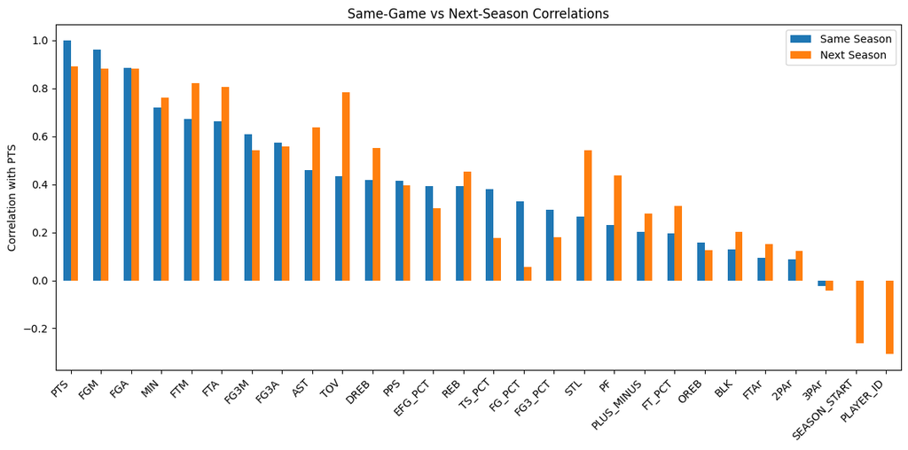

```python
compare = pd.concat(
    [corr_with_pts.rename("Same Season"),
     corr_with_future_pts.rename("Next Season")],
    axis=1
)

compare.plot(kind="bar", figsize=(12,6))
plt.xticks(rotation=45, ha="right")
plt.ylabel("Correlation with PTS")
plt.title("Same-Game vs Next-Season Correlations")
plt.tight_layout()
plt.show()
```

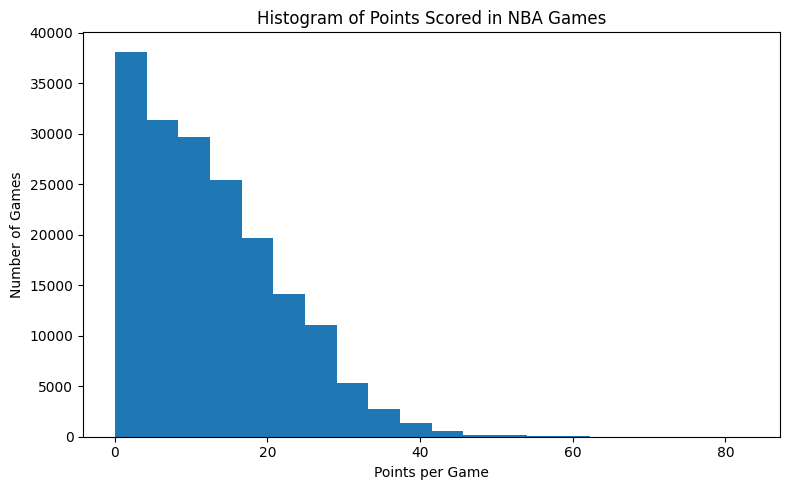

```python
plt.figure(figsize=(8,5))
plt.hist(all_years_game_stats["PTS"], bins=20)

plt.xlabel("Points per Game")
plt.ylabel("Number of Games")
plt.title("Histogram of Points Scored in NBA Games")

plt.tight_layout()
plt.show()
```

It may be helpful to see how skewed some of our statistics are, as this provides insight into whether the distribution of each variable is symmetric or heavily influenced by extreme values, which in turn can affect the interpretation of correlations and any downstream modeling results.

```python
summary = all_years_game_stats[cols].agg(["skew"]).T
display(summary)
```

|  | skew |
| --- | --- |
| MIN | -0.500392 |
| FGM | 0.778264 |
| FGA | 0.625386 |
| FG_PCT | 0.091718 |
| FG3M | 1.470281 |
| FG3A | 0.947870 |
| FG3_PCT | 0.559123 |
| FTM | 1.808668 |
| FTA | 1.674810 |
| FT_PCT | -1.191088 |
| OREB | 1.872603 |
| DREB | 1.134065 |
| REB | 1.167412 |
| AST | 1.447891 |
| STL | 1.424740 |
| BLK | 2.293179 |
| TOV | 1.253557 |
| PF | 0.437362 |
| TS_PCT | 0.037882 |
| EFG_PCT | 0.105057 |
| PPS | 0.611334 |
| 3PAr | 0.430689 |
| 2PAr | -0.406557 |
| FTAr | 4.379638 |
| PLUS_MINUS | 0.095260 |
| PTS | 0.822793 |

It may also be interesting to see how a player's points develops over their career. Because LeBron has the most data entries in this set, with 2003 and 2004 being just him, he will be a frequent testing player going forward in the project.

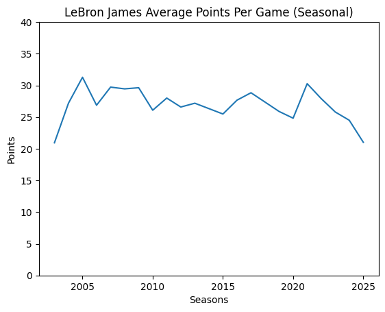

```python
lebron_season_averages = all_years_game_stats.groupby(["PLAYER_NAME","SEASON_START"])["PTS"].mean()["lebron james"] # calculate average pts per game
plt.plot(lebron_season_averages)
plt.xlabel("Seasons")
plt.ylabel("Points")
plt.ylim(0,40) # force yaxis to have a better range to improve visability.
plt.title("LeBron James Average Points Per Game (Seasonal)")
```